# DATA 624 | Predictive Analytics

Gabriella Martinez

2/11/2022

# Homework 2: Decomposition

## Instructions

Do exercises 3.1, 3.2, 3.3, 3.4, 3.5, 3.7, 3.8 and 3.9 from [Forecasting: Principles and Practice](https://otexts.com/fpp3/) book. Please submit both your Rpubs link as well as attach the .rmd file with your code.

## Packages

```r
library(fpp3)
library(latex2exp)
library(forecast)
library(seasonal)
```

## Exercises

### 3.1

Consider the GDP information in `global_economy`. Plot the GDP per capita for each country over time. Which country has the highest GDP per capita? How has this changed over time?

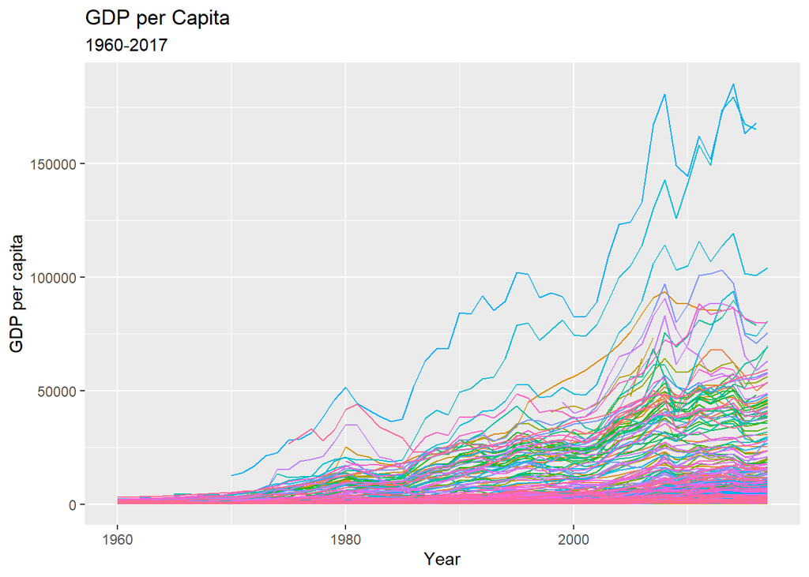

```r
global_economy %>%
  autoplot(GDP/Population, show.legend =  FALSE) +
    labs(title = "GDP per Capita",
       subtitle = "1960-2017",
       x = "Year",
       y = "GDP per capita")
```

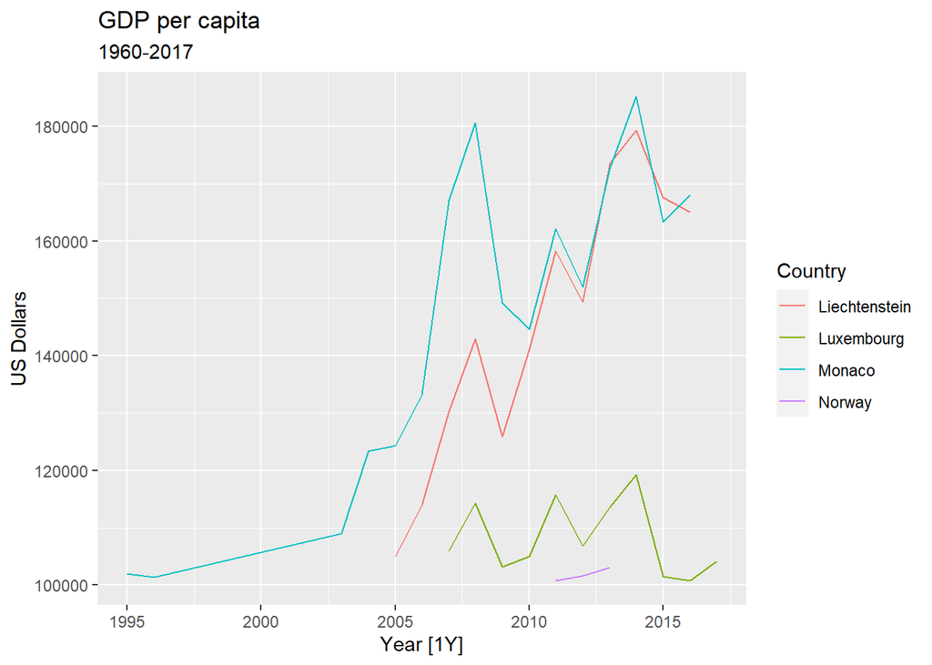

```r
global_economy <- global_economy %>%
  mutate(GDP_per_capita = GDP/Population)

global_economy %>%
  filter(GDP_per_capita > 100000) %>%
  autoplot(GDP_per_capita) +
  labs(title= "GDP per capita",
       subtitle = "1960-2017",
       y = "US Dollars")
```

```r
arrange(global_economy, desc(GDP_per_capita))
```

```
## # A tsibble: 15,150 x 10 [1Y]
## # Key:       Country [263]
##    Country       Code   Year         GDP Growth   CPI Imports Exports Population
##    <fct>         <fct> <dbl>       <dbl>  <dbl> <dbl>   <dbl>   <dbl>      <dbl>
##  1 Monaco        MCO    2014 7060236168.  7.18     NA      NA      NA      38132
##  2 Monaco        MCO    2008 6476490406.  0.732    NA      NA      NA      35853
##  3 Liechtenstein LIE    2014 6657170923. NA        NA      NA      NA      37127
##  4 Liechtenstein LIE    2013 6391735894. NA        NA      NA      NA      36834
##  5 Monaco        MCO    2013 6553372278.  9.57     NA      NA      NA      37971
##  6 Monaco        MCO    2016 6468252212.  3.21     NA      NA      NA      38499
##  7 Liechtenstein LIE    2015 6268391521. NA        NA      NA      NA      37403
##  8 Monaco        MCO    2007 5867916781. 14.4      NA      NA      NA      35111
##  9 Liechtenstein LIE    2016 6214633651. NA        NA      NA      NA      37666
## 10 Monaco        MCO    2015 6258178995.  4.94     NA      NA      NA      38307
## # ... with 15,140 more rows, and 1 more variable: GDP_per_capita <dbl>
```

### 3.2

For each of the following series, make a graph of the data. If transforming seems appropriate, do so and describe the effect.

- United States GDP from `global_economy`.
- Slaughter of Victorian “Bulls, bullocks and steers” in `aus_livestock`.
- Victorian Electricity Demand from `vic_elec`.
- Gas production from `aus_production`.

**United States GDP from** `global_economy`

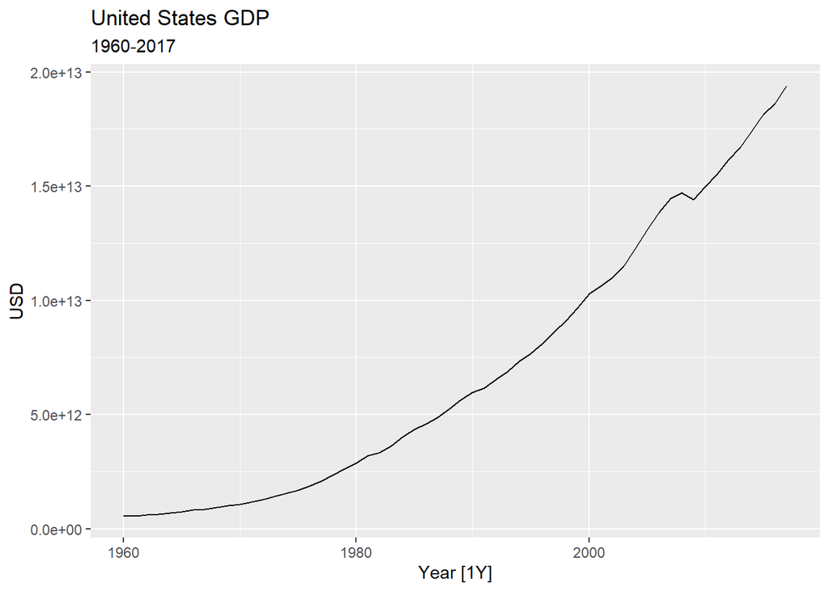

```r
global_economy %>%
  filter(Country == "United States") %>%
  autoplot() +
  labs(title= "United States GDP",
       subtitle = "1960-2017",
       y = "USD")
```

**Slaughter of Victorian “Bulls, bullocks and steers” in** `aus_livestock`.

```r
aus_livestock %>%
  filter(Animal == "Bulls, bullocks and steers",
         State == "Victoria") %>%
  head()
```

```
## # A tsibble: 6 x 4 [1M]
## # Key:       Animal, State [1]
##      Month Animal                     State     Count
##      <mth> <fct>                      <fct>     <dbl>
## 1 1976 Jul Bulls, bullocks and steers Victoria 109200
## 2 1976 Aug Bulls, bullocks and steers Victoria  94700
## 3 1976 Sep Bulls, bullocks and steers Victoria  95500
## 4 1976 Oct Bulls, bullocks and steers Victoria  94800
## 5 1976 Nov Bulls, bullocks and steers Victoria  94100
## 6 1976 Dec Bulls, bullocks and steers Victoria  98300
```

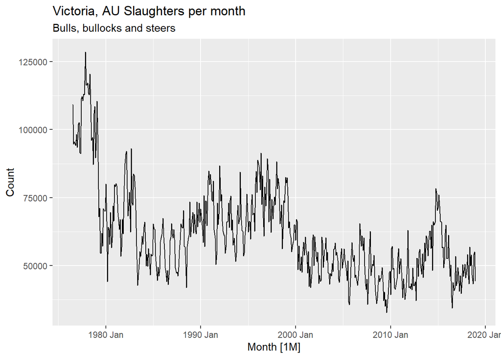

```r
aus_livestock %>%
  filter(Animal == "Bulls, bullocks and steers",
         State == "Victoria") %>%
  autoplot() +
  labs(title = "Victoria, AU Slaughters per month",
       subtitle= "Bulls, bullocks and steers")
```

**Victorian Electricity Demand from** `vic_elec`.

```r
head(vic_elec)
```

```
## # A tsibble: 6 x 5 [30m] <Australia/Melbourne>
##   Time                Demand Temperature Date       Holiday
##   <dttm>               <dbl>       <dbl> <date>     <lgl>
## 1 2012-01-01 00:00:00  4383.        21.4 2012-01-01 TRUE
## 2 2012-01-01 00:30:00  4263.        21.0 2012-01-01 TRUE
## 3 2012-01-01 01:00:00  4049.        20.7 2012-01-01 TRUE
## 4 2012-01-01 01:30:00  3878.        20.6 2012-01-01 TRUE
## 5 2012-01-01 02:00:00  4036.        20.4 2012-01-01 TRUE
## 6 2012-01-01 02:30:00  3866.        20.2 2012-01-01 TRUE
```

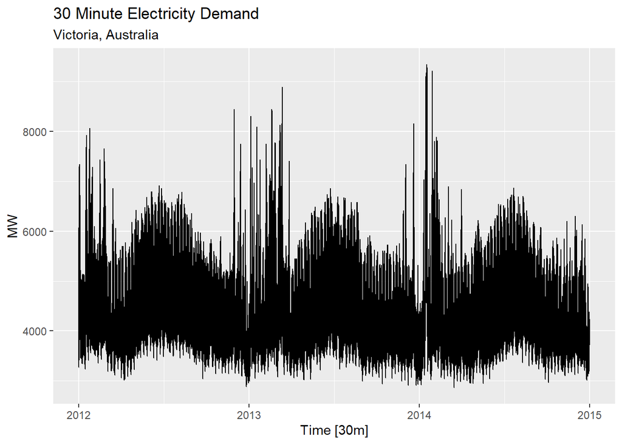

```r
autoplot(vic_elec)+
    labs(title= "30 Minute Electricity Demand",
         subtitle= "Victoria, Australia",
         y = "MW")
```

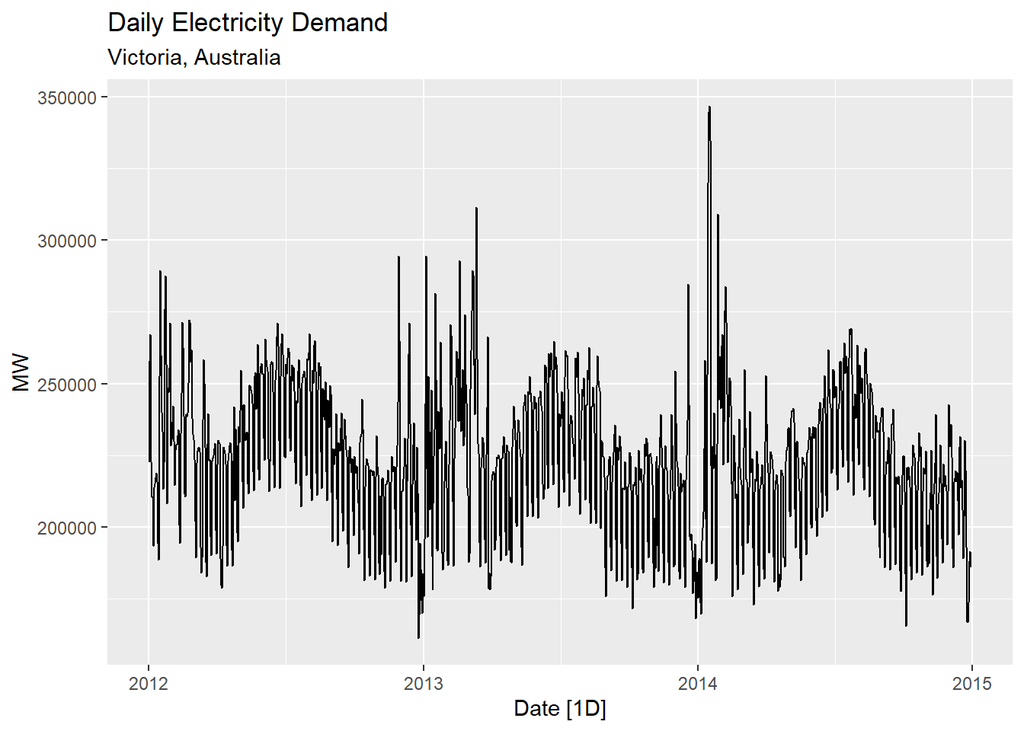

```r
vic_elec %>%
    index_by(Date) %>%
    summarise(Demand = sum(Demand)) -> daily_demand

daily_demand %>% autoplot(Demand) +
    labs(title= "Daily Electricity Demand",
         subtitle= "Victoria, Australia",
         y = "MW")
```

A calendar transformation to show aggregated daily amounts was most appropriate in this case in comparison to the original 30 minute data. The plot shows strong seasonality within each year with higher peaks in the first few months of each year and another smaller peak towards the middle of each year. The same conclusions can be drawn out of the 30 minute plot but this is a bit easier to see the true max and min points.

**Gas production from** `aus_production`

```r
head(aus_production)
```

```
## # A tsibble: 6 x 7 [1Q]
##   Quarter  Beer Tobacco Bricks Cement Electricity   Gas
##     <qtr> <dbl>   <dbl>  <dbl>  <dbl>       <dbl> <dbl>
## 1 1956 Q1   284    5225    189    465        3923     5
## 2 1956 Q2   213    5178    204    532        4436     6
## 3 1956 Q3   227    5297    208    561        4806     7
## 4 1956 Q4   308    5681    197    570        4418     6
## 5 1957 Q1   262    5577    187    529        4339     5
## 6 1957 Q2   228    5651    214    604        4811     7
```

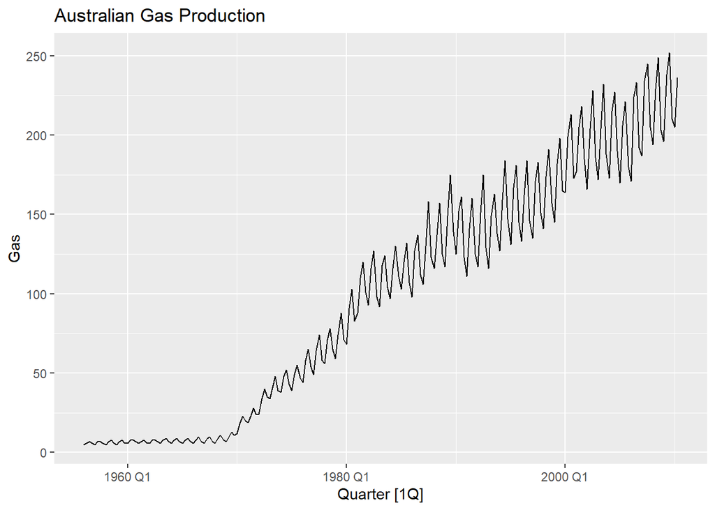

```r
autoplot(aus_production, Gas) +
  labs(title= "Australian Gas Production")
```

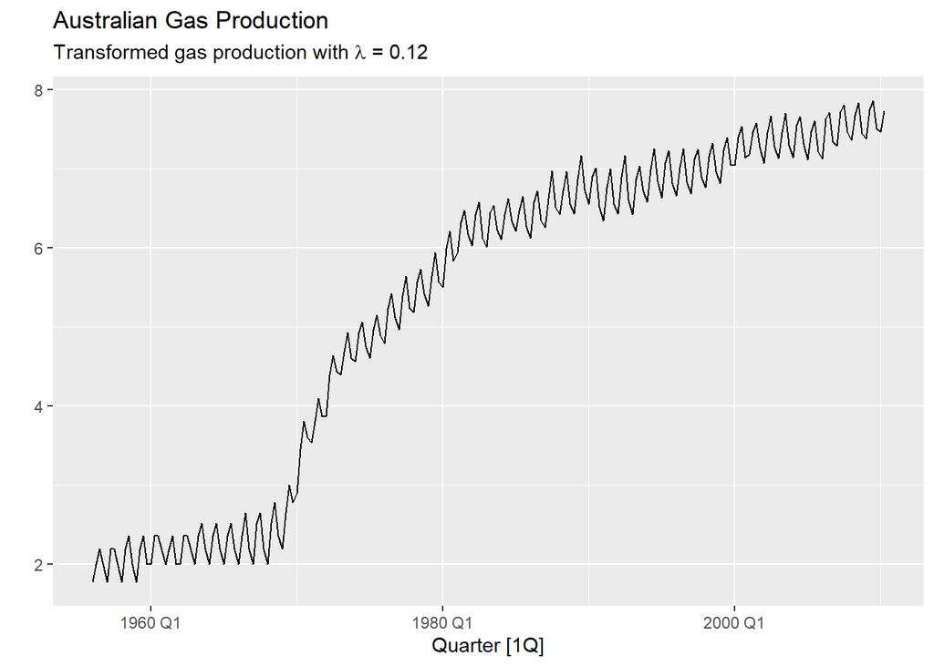

```r
lambda <- aus_production %>%
  features(Gas, features = guerrero) %>%
  pull(lambda_guerrero)
aus_production %>%
  autoplot(box_cox(Gas, lambda)) +
  labs(y = "",
       title= "Australian Gas Production",
       subtitle = latex2exp::TeX(paste0(
         "Transformed gas production with $\\lambda$ = ",
         round(lambda,2))))
```

A transformation would be useful given that the data shows variation with the level of the series. Using the Guerrero feature, an optimal value of lambda = 0.12 was obtained. As seen above, the transformation has minimized the seasonal variation across the whole series and has provided an almost consistent amplitude throughout (except at about Q1 1970 where the amplitude is largest).

### 3.3

Why is a Box-Cox transformation unhelpful for the `canadian_gas` data?

```r
head(canadian_gas)
```

```
## # A tsibble: 6 x 2 [1M]
##      Month Volume
##      <mth>  <dbl>
## 1 1960 Jan   1.43
## 2 1960 Feb   1.31
## 3 1960 Mar   1.40
## 4 1960 Apr   1.17
## 5 1960 May   1.12
## 6 1960 Jun   1.01
```

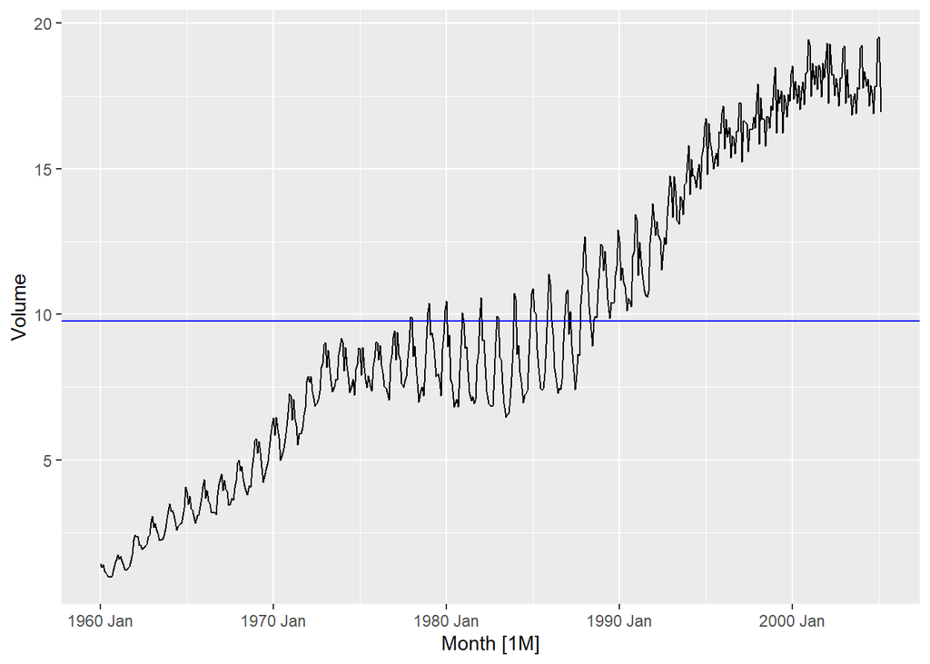

```r
autoplot(canadian_gas, .vars = Volume)  +
  geom_line() +
  geom_hline(yintercept = mean(canadian_gas$Volume), color="blue")
```

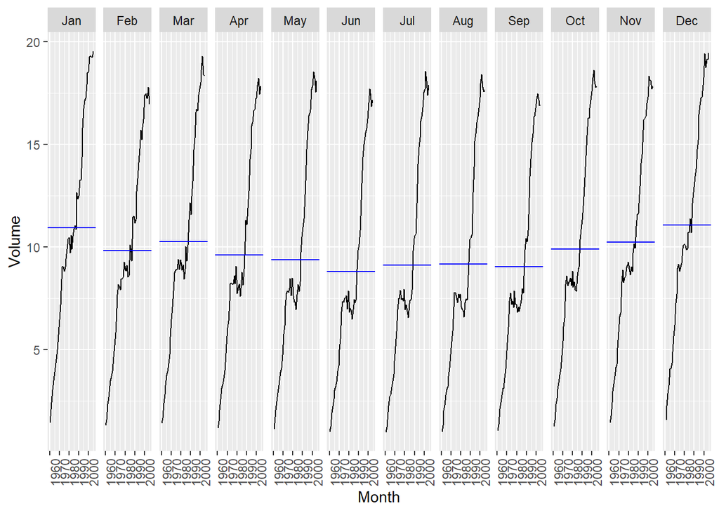

```r
canadian_gas%>%
  summarise(Volume = sum(Volume)) %>%
  gg_subseries(Volume)
```

In section 3.1, under Mathematical transformations, “If the data shows variation that increases or decreases with the level of the series, then mathematical transformation” such as a Box-Cox transformation “can be useful.” Based on the above, it doesn’t look like the variation increases/decreases with the level of the series.

Key term/phrase: “level of a series”  
Definition: Level of a series refers to the average value in the series.[^1] [^2]

### 3.4

What Box-Cox transformation would you select for your retail data (from Exercise 8 in Section 2.10)?

```r
set.seed(555)

myseries <- aus_retail %>%
  filter(`Series ID` == sample(aus_retail$`Series ID`,1))

head(myseries)
```

```
## # A tsibble: 6 x 5 [1M]
## # Key:       State, Industry [1]
##   State             Industry          `Series ID`    Month Turnover
##   <chr>             <chr>             <chr>          <mth>    <dbl>
## 1 Western Australia Department stores A3349434X   1982 Apr     36.5
## 2 Western Australia Department stores A3349434X   1982 May     43.7
## 3 Western Australia Department stores A3349434X   1982 Jun     38
## 4 Western Australia Department stores A3349434X   1982 Jul     42
## 5 Western Australia Department stores A3349434X   1982 Aug     38.5
## 6 Western Australia Department stores A3349434X   1982 Sep     40.2
```

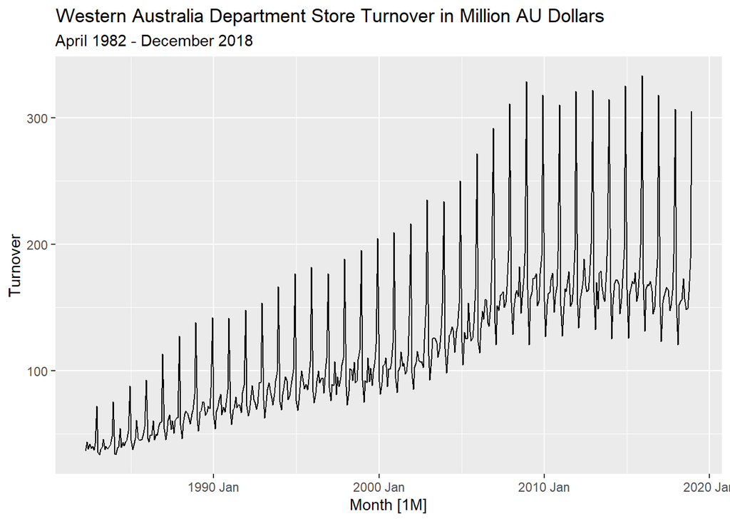

```r
autoplot(myseries, .vars = Turnover) +
  labs(title= "Western Australia Department Store Turnover in Million AU Dollars",
       subtitle = "April 1982 - December 2018")
```

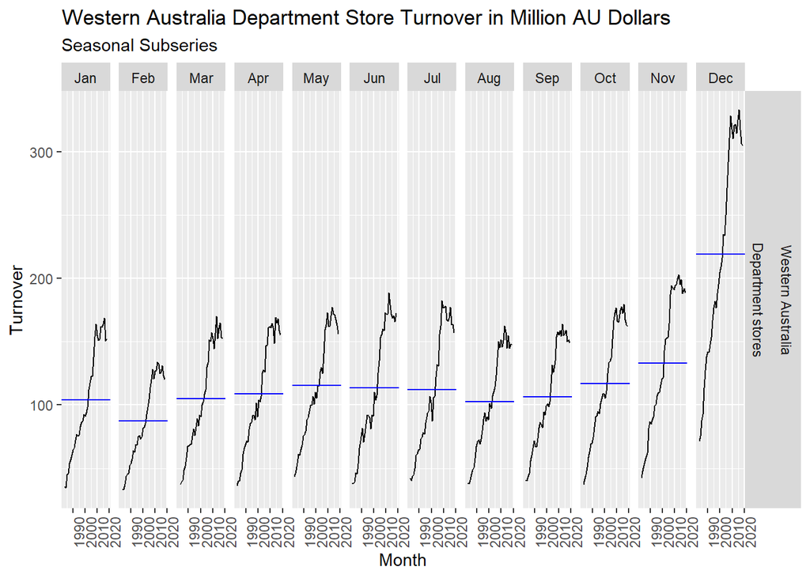

```r
gg_subseries(myseries, y = Turnover) +
  labs(title= "Western Australia Department Store Turnover in Million AU Dollars",
       subtitle = "Seasonal Subseries")
```

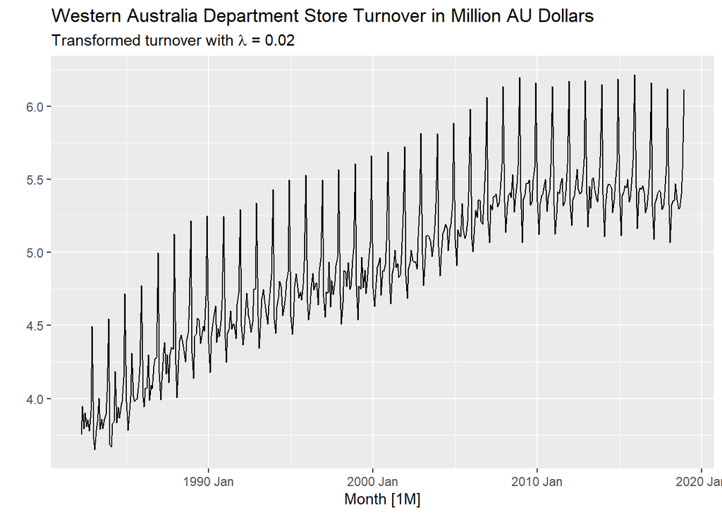

```r
lambda <- myseries %>%
  features(Turnover, features = guerrero) %>%
  pull(lambda_guerrero)

myseries %>%
  autoplot(box_cox(Turnover, lambda)) +
  labs(y = "", title= "Western Australia Department Store Turnover in Million AU Dollars",
       subtitle = latex2exp::TeX(paste0(
         "Transformed turnover with $\\lambda$ = ",
         round(lambda,2))))
```

The above shows the transformed retail turn over for the series ID `A3349434X` with the $\lambda$ parameter of 0.02 chosen using the Guerrero method. The transformation shows a more tamed and consistent amplitude in Turnover throughout in comparison to the original plot of the Turnover.

### 3.5

For the following series, find an appropriate Box-Cox transformation in order to stabilize the variance.

- Tobacco from `aus_production`
- Economy class passengers between Melbourne and Sydney from `ansett`
- Pedestrian counts at Southern Cross Station from `pedestrian`

**Tobacco from** `aus_production`

```r
head(aus_production)
```

```
## # A tsibble: 6 x 7 [1Q]
##   Quarter  Beer Tobacco Bricks Cement Electricity   Gas
##     <qtr> <dbl>   <dbl>  <dbl>  <dbl>       <dbl> <dbl>
## 1 1956 Q1   284    5225    189    465        3923     5
## 2 1956 Q2   213    5178    204    532        4436     6
## 3 1956 Q3   227    5297    208    561        4806     7
## 4 1956 Q4   308    5681    197    570        4418     6
## 5 1957 Q1   262    5577    187    529        4339     5
## 6 1957 Q2   228    5651    214    604        4811     7
```

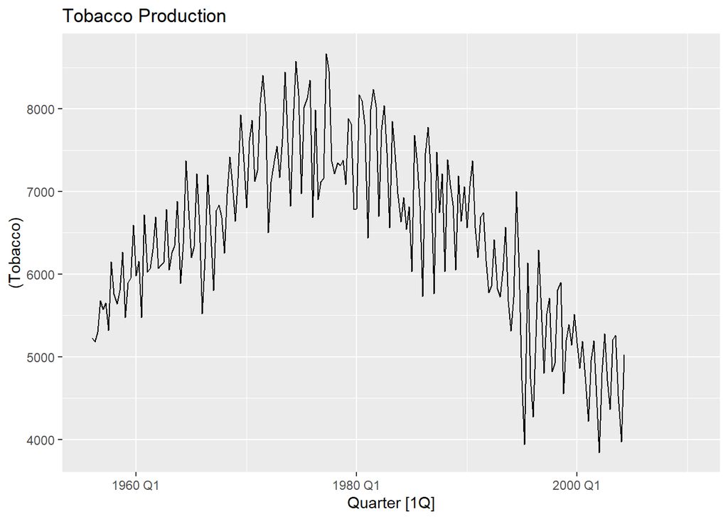

```r
autoplot(aus_production, (Tobacco)) +
  labs(title = "Tobacco Production")
```

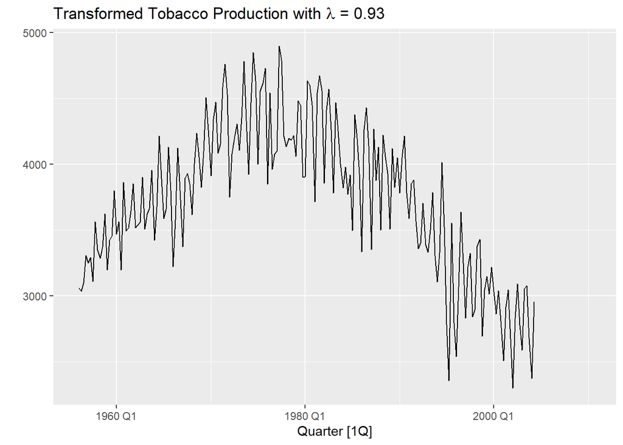

```r
aus_tobacco <- aus_production %>%
  select(Quarter, Tobacco)

lambda <- aus_tobacco %>%
  features(Tobacco, features = guerrero) %>%
  pull(lambda_guerrero)

aus_tobacco %>%
  autoplot(box_cox(Tobacco, lambda)) +
  labs(y = "",
       title = latex2exp::TeX(paste0(
         "Transformed Tobacco Production with $\\lambda$ = ",
         round(lambda,2))))
```

Given our $\lambda$ is near 1 with value of 0.93, there is no substantive transformation resulting from the Box-Cox transformation.[^3]

**Economy class passengers between Melbourne and Sydney from** `ansett`

```r
head(ansett)
```

```
## # A tsibble: 6 x 4 [1W]
## # Key:       Airports, Class [1]
##       Week Airports Class    Passengers
##     <week> <chr>    <chr>         <dbl>
## 1 1989 W28 ADL-PER  Business        193
## 2 1989 W29 ADL-PER  Business        254
## 3 1989 W30 ADL-PER  Business        185
## 4 1989 W31 ADL-PER  Business        254
## 5 1989 W32 ADL-PER  Business        191
## 6 1989 W33 ADL-PER  Business        136
```

```r
unique(ansett$Airports)
```

```
##  [1] "ADL-PER" "MEL-ADL" "MEL-BNE" "MEL-OOL" "MEL-PER" "MEL-SYD" "SYD-ADL"
##  [8] "SYD-BNE" "SYD-OOL" "SYD-PER"
```

```r
econ_mel <- ansett %>%
  filter(Airports == "MEL-SYD",
         Class == "Economy")
```

```
## Plot variable not specified, automatically selected `.vars = Passengers`
```

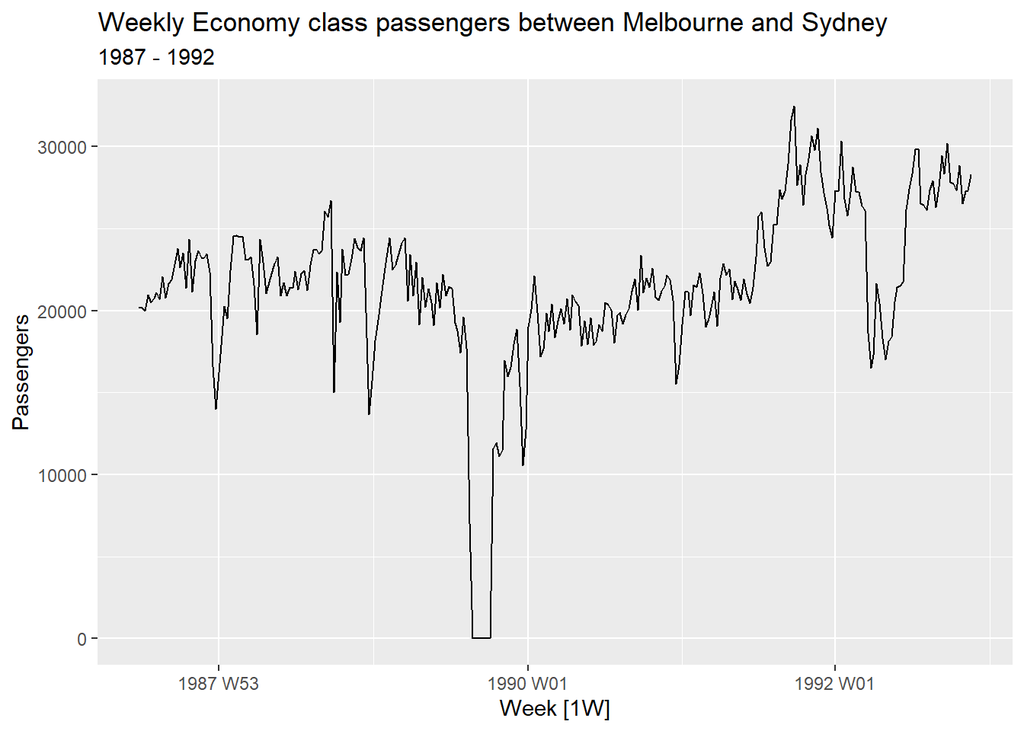

```r
autoplot(econ_mel) +
  labs(title= "Weekly Economy class passengers between Melbourne and Sydney",
       subtitle = "1987 - 1992")
```

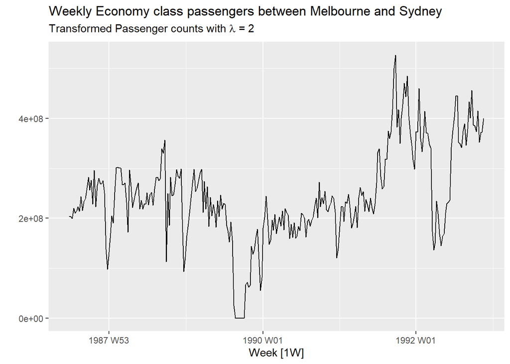

```r
lambda <- econ_mel %>%
  features(Passengers, features = guerrero) %>%
  pull(lambda_guerrero)

econ_mel %>%
  autoplot(box_cox(Passengers, lambda)) +
  labs(y = "",
       title= "Weekly Economy class passengers between Melbourne and Sydney",
       subtitle = latex2exp::TeX(paste0(
         "Transformed Passenger counts with $\\lambda$ = ",
         round(lambda,2))))
```

**Pedestrian counts at Southern Cross Station from** `pedestrian`

```r
head(pedestrian)
```

```
## # A tsibble: 6 x 5 [1h] <Australia/Melbourne>
## # Key:       Sensor [1]
##   Sensor         Date_Time           Date        Time Count
##   <chr>          <dttm>              <date>     <int> <int>
## 1 Birrarung Marr 2015-01-01 00:00:00 2015-01-01     0  1630
## 2 Birrarung Marr 2015-01-01 01:00:00 2015-01-01     1   826
## 3 Birrarung Marr 2015-01-01 02:00:00 2015-01-01     2   567
## 4 Birrarung Marr 2015-01-01 03:00:00 2015-01-01     3   264
## 5 Birrarung Marr 2015-01-01 04:00:00 2015-01-01     4   139
## 6 Birrarung Marr 2015-01-01 05:00:00 2015-01-01     5    77
```

View unique `Sensor` categories:

```r
unique(pedestrian$Sensor)
```

```
## [1] "Birrarung Marr"                "Bourke Street Mall (North)"
## [3] "QV Market-Elizabeth St (West)" "Southern Cross Station"
```

```r
scs_pedestrian <- pedestrian %>%
  filter(Sensor == "Southern Cross Station")
```

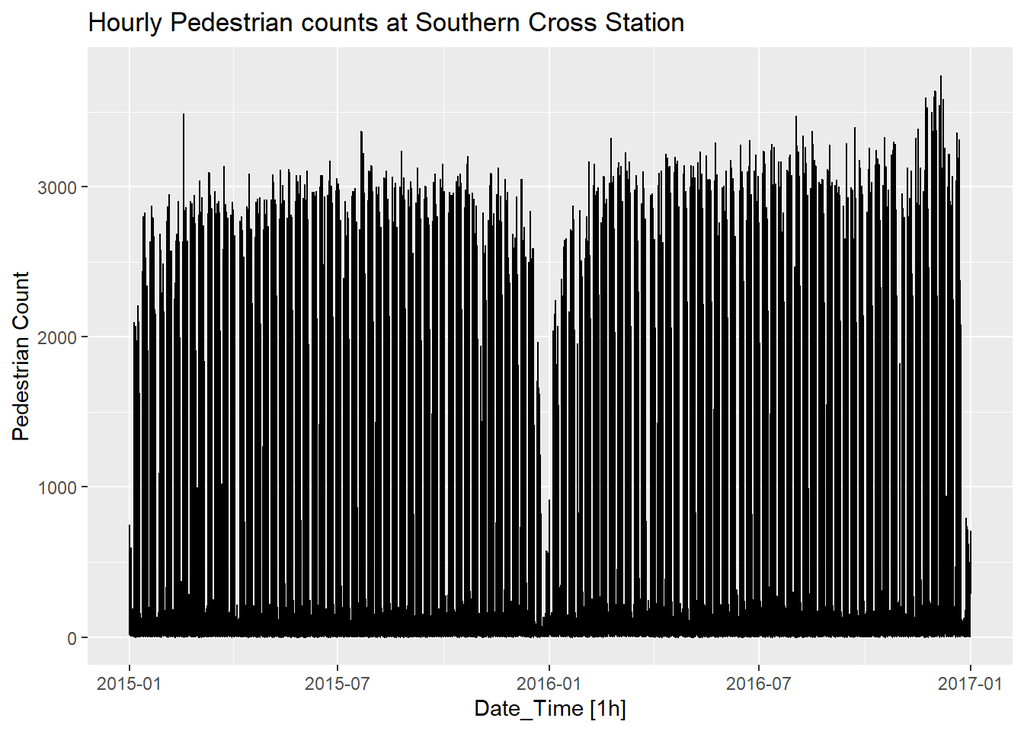

```r
autoplot(scs_pedestrian, Count) +
  labs(y = "Pedestrian Count",
         title = "Hourly Pedestrian counts at Southern Cross Station")
```

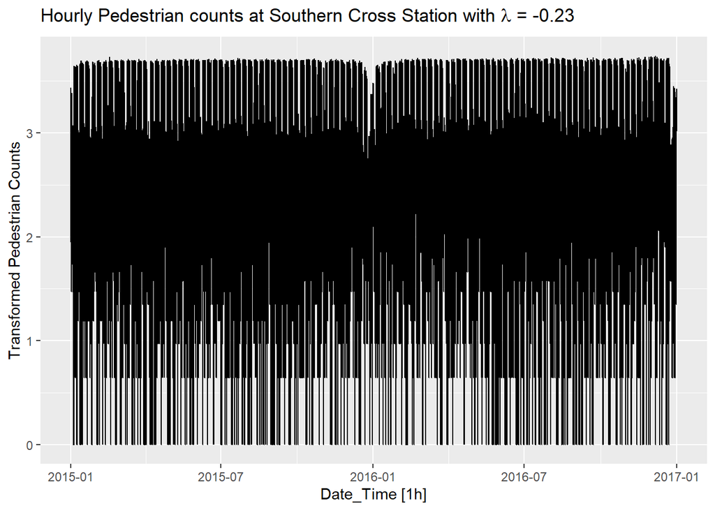

```r
#compute lambda
lambda_scs <- scs_pedestrian %>%
  features(Count, features = guerrero) %>%
  pull(lambda_guerrero)

#plot
scs_pedestrian %>%
  autoplot(box_cox(Count, lambda_scs)) +
  labs(y = "Transformed Pedestrian Counts",
       title = latex2exp::TeX(paste0(
         "Hourly Pedestrian counts at Southern Cross Station with $\\lambda$ = ",
         round(lambda_scs,2))))
```

### 3.7

Consider the last five years of the Gas data from `aus_production`.

```r
gas <- tail(aus_production, 5*4) %>% select(Gas)
```

1. Plot the time series. Can you identify seasonal fluctuations and/or a trend-cycle?

```r
head(gas)
```

```
## # A tsibble: 6 x 2 [1Q]
##     Gas Quarter
##   <dbl>   <qtr>
## 1   221 2005 Q3
## 2   180 2005 Q4
## 3   171 2006 Q1
## 4   224 2006 Q2
## 5   233 2006 Q3
## 6   192 2006 Q4
```

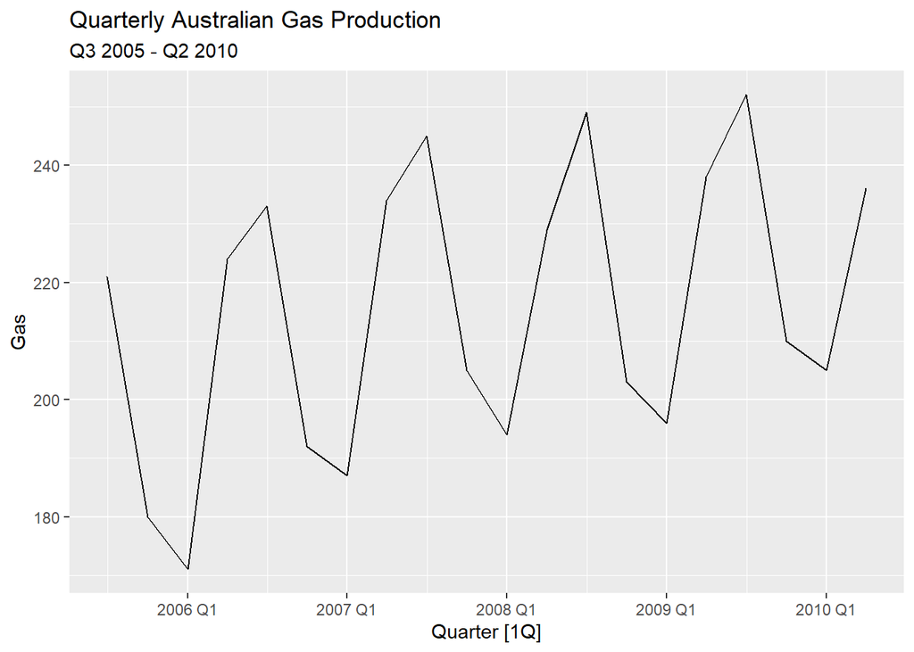

```r
autoplot(gas, Gas)+
  labs(title = "Quarterly Australian Gas Production",
       subtitle = "Q3 2005 - Q2 2010")
```

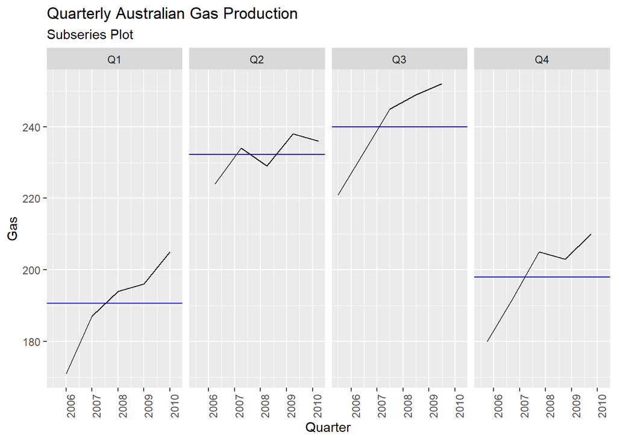

```r
gas %>%
  gg_subseries(Gas) +
  labs(title = "Quarterly Australian Gas Production",
       subtitle = "Subseries Plot")
```

2. Use `classical_decomposition` with `type=multiplicative` to calculate the trend-cycle and seasonal indices.

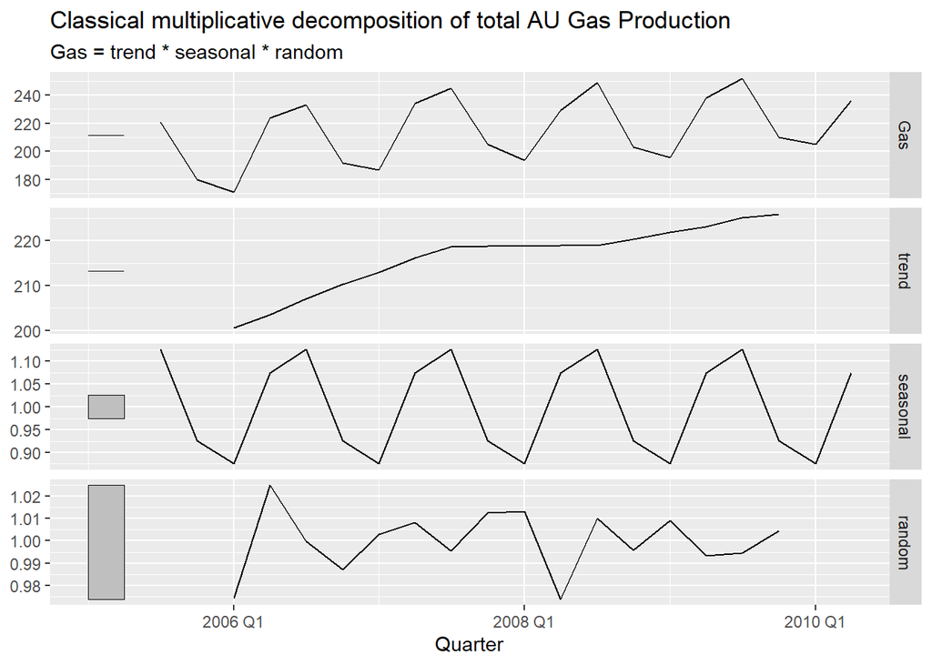

```r
gas %>%
  model(classical_decomposition(Gas, type = "multiplicative")) %>%
  components() %>%
  autoplot() +
  labs(title = "Classical multiplicative decomposition of total AU Gas Production")
```

3. Do the results support the graphical interpretation from part a?  
   Yes, the results support the initial findings noted in part a.
4. Compute and plot the seasonally adjusted data.

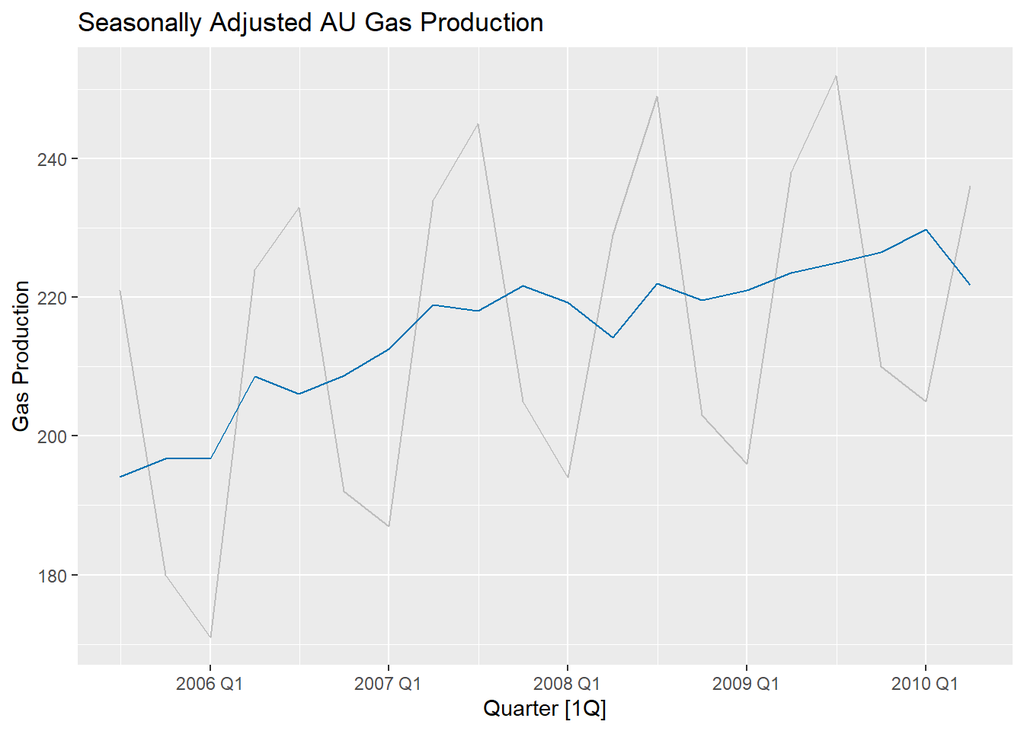

```r
#computation
decomp <- gas %>%
  model(stl= STL(Gas))

#plot
components(decomp) %>% as_tsibble() %>%
  autoplot(Gas, colour = "gray", colour = "Data") +
  geom_line(aes(y=season_adjust), colour = "#0072B2") +
   labs(y = "Gas Production",
       title = "Seasonally Adjusted AU Gas Production")
```

Seasonally adjusted gas production data (blue) and the original data (grey).

5. Change one observation to be an outlier (e.g., add 300 to one observation), and recompute the seasonally adjusted data. What is the effect of the outlier?

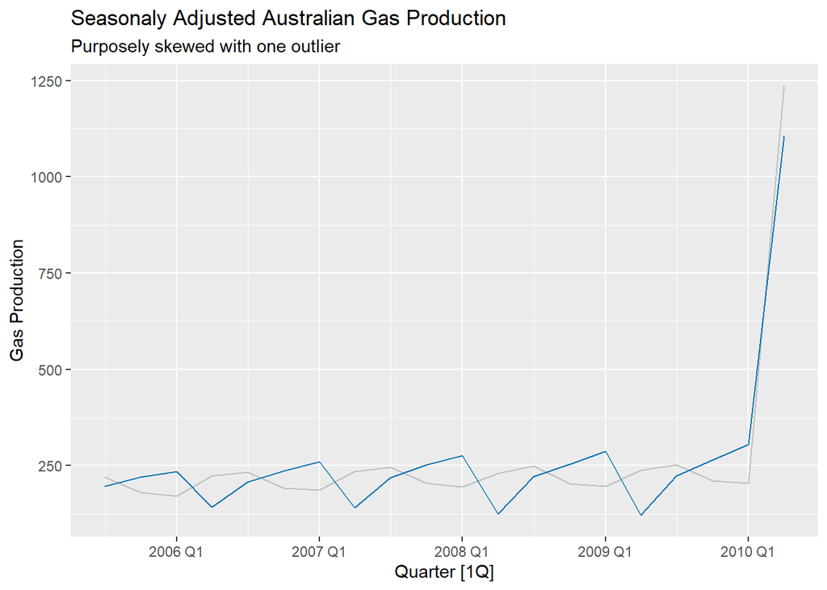

```r
#change one observation to be an outlier
gas_outlier <- gas
gas_outlier$Gas[20] <- gas_outlier$Gas[20] + 1000

#recompute the seasonally adjusted data

# STL decomposition
dcmp <- gas_outlier %>%
  model(stl = STL(Gas))

#Compute and plot the seasonally adjusted data
components(dcmp) %>%
  as_tsibble() %>%
  autoplot(Gas, colour = "gray") +
  geom_line(aes(y=season_adjust), colour = "#0072B2") +
  labs(y = "Gas Production",
       title = "Seasonaly Adjusted Australian Gas Production",
       subtitle = "Purposely skewed with one outlier")
```

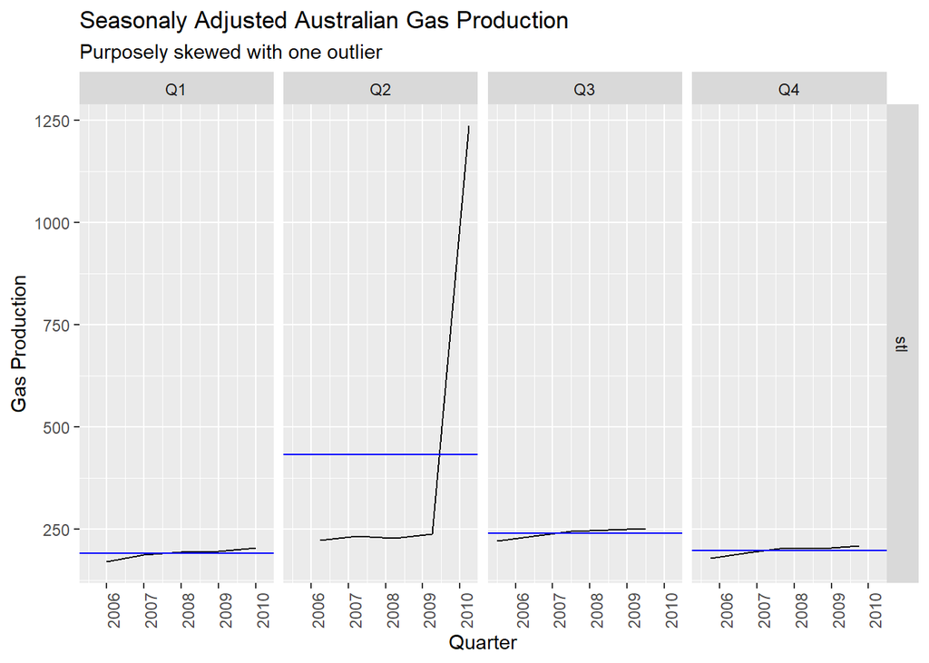

```r
components(dcmp) %>%
  as_tsibble() %>%
gg_subseries(y = Gas) +
  labs(y = "Gas Production",
       title = "Seasonaly Adjusted Australian Gas Production",
       subtitle = "Purposely skewed with one outlier")
```

6. Does it make any difference if the outlier is near the end rather than in the middle of the time series?

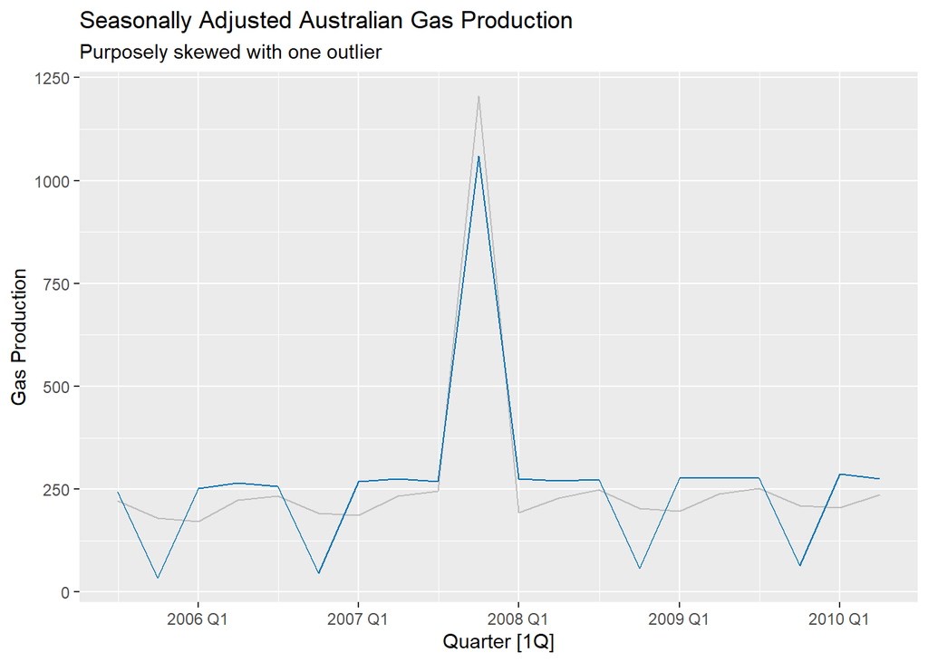

```r
#change one observation to be an outlier
gas_outlier_2 <- gas
gas_outlier_2$Gas[10] <- gas_outlier_2$Gas[10] + 1000

#recompute the seasonally adjusted data

# STL decomposition
dcmp_2 <- gas_outlier_2 %>%
  model(stl = STL(Gas))

#Compute and plot the seasonally adjusted data
components(dcmp_2) %>%
  as_tsibble() %>%
  autoplot(Gas, colour = "gray") +
  geom_line(aes(y=season_adjust), colour = "#0072B2") +
  labs(y = "Gas Production",
       title = "Seasonally Adjusted Australian Gas Production",
       subtitle = "Purposely skewed with one outlier")
```

### 3.8

Recall your retail time series data (from Exercise 8 in Section 2.10). Decompose the series using X-11. Does it reveal any outliers, or unusual features that you had not noticed previously?

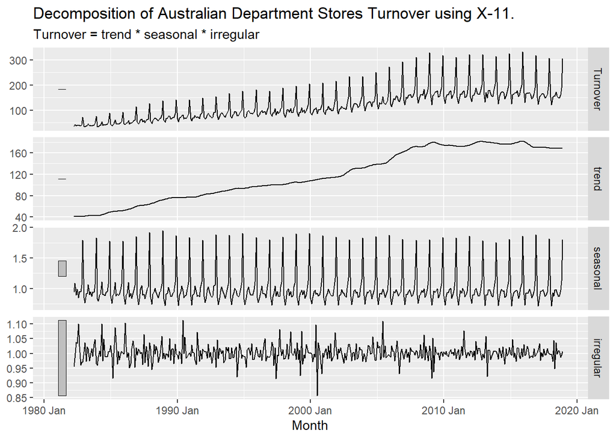

```r
x11_dcmp <- myseries %>%
  model(x11 = X_13ARIMA_SEATS(Turnover ~ x11())) %>%
  components()
autoplot(x11_dcmp)+
  labs(title =
    "Decomposition of Australian Department Stores Turnover using X-11.")
```

An unusual feature or outlier can be noted in the `irregular` component around the year 2000 with a significant downward spike. The component doesn’t seem like it can be attributed to a trend although there are other less significant downward and upward spikes throughout the `irregular` component at varying points in time.

### 3.9

Figures [3.19](https://otexts.com/fpp3/decomposition-exercises.html#fig:labour) and [3.20](https://otexts.com/fpp3/decomposition-exercises.html#fig:labour2) show the result of decomposing the number of persons in the civilian labour force in Australia each month from February 1978 to August 1995.

1. Write about 3–5 sentences describing the results of the decomposition. Pay particular attention to the scales of the graphs in making your interpretation.
- The scales of the `value` and `trend` plots range from about 6500 to 9000
- The scale of the `season_year` plot ranges from -100 to 100
- The scale of the `remainder` plot range from -400 to 100 with the maximum value between 50 and 100. This value represents how many people either entered (+) or exited (-) the labour force.
- As expected from the `value` plot, there is an increasing trend in the `trend` subplot
- The `season_year` plot does not show a fixed seasonality for the data and shows the greatest change in seasonality between 1987 to 1990
- The `remainder` plot captures the randomness left over after the `trend` and `season_year` components are extracted. It most notably shows the variation noted in the `value` plot for years around 1991 and 1992. The stark dips or troughs in `remainder` show that there were two major instances where the labour force decreased significantly, once with a decrease of about 400 and another decrease of about 350 which were almost back to back.
- Immediately before the largest dip at -400, there was another dip at -200 which may have been a preview of what was about to happen with the next and largest decrease. Between the decrease of 400 and 350, there was an increase of up to around 50 which may be attributed to holidays and the need for workers back in the the workforce to meet demands.
2. Is the recession of 1991/1992 visible in the estimated components?  
   Yes, the recession is visible in the estimated components as noted above.

## References

[^1]: https://machinelearningmastery.com/decompose-time-series-data-trend-seasonality/
[^2]: https://otexts.com/fpp3/subseries.html
[^3]: https://robjhyndman.com/eindhoven/2-2-Transformations.pdf